# Pair Assignment 3: Gathering, Cleaning, Merging and Exploring our Data

Course: Introduction to Collaborative Social Science Data Analysis

Malte Berneaud-Kötz & Jonas Markgraf Hertie School of Governance

19 April 2016

# 1. Gathering the Data

## 1.1. *Sparkassen* Board Membership Data

We use a hand-collect a unique panel dataset containing information on board members in Bavaria’s *Sparkassen*[^1]. This data is available on *Bundesanzeiger* for the years from 2006 to 2015. The dataset includes detailed information on board member profiles (name, occupation, and position within board) which enables us to identify mayors on bank boards.

## 1.2. Municipal Election Data

A database on mayoral elections in Bavaria is available from the state statistical office upon request. It contains information on direct municipal elections between 1948 and 2014 including election date; name of all candidates and their vote shares; and party affiliation. With this database we are covering 79 of the 416 German *Sparkassen* (19%) and 2,099 municipalities (19% of all municipalities in Germany).

After obtaining the raw data, we cleaned the data set and subsequently created additional variables needed in our analysis. The individual steps taken are outline in the subsequent sections.

# 2. Cleaning the Data

## 2.1. *Sparkassen* Data

In order to make our analysis more accessible, we re-defined the variable names in the *Sparkassen* dataset. Moreover, we standardized them to follow use underscores to seperate words and use lower case and deleted redundant whitespaces.

Furthermore, we created an additional variable for top positions in *Sparkassen* boards. The raw data includes information on the position of the respective person (normal board member, vice chairman or chairman); since chairmen and vice chairmen alternate over the years in Bavarian savings banks, there is no difference between chairmen and vice chairmen in reality and they can be amalgamated into one category (*top position*).

Finally, we created four sub-data frames by subsetting the initial dataframe in order to analyze different aspects of *Sparkassen* boards in greater detail. Hence, we created a subset containing unique board member profiles, another one with unique profiles of mayors on the board, a data frame with only persons in top positions on the board, and a data frame with unique banks.

## 2.2. Creating Additional Variables

In addition to the variables available in the data set already, we created variables (1) distinguishing ‘first time mayors’, (2) identifying competitive elections where there were more than one candidate, (3) the number of times a single mayor was elected, which allowed us to identify mayor’s first re-election. This last point is important because our research is interested in the first re-election of mayors specifically.

## 2.3. Municipal Election Data

The municipal election data as provided by the Bavarian Statistical Service was provided as an Excel worksheet, which also meant that the columns where named in a way which was not computer-readable. As a result, we had to clean the names of the data set almost entirely. Aside from containing spaces, they also frequently contained line breaks and carriage returns.

Aside from the variables included in the data set, we extracted information on PhD titles from the names of the candidates from the variable for candidate’s name and created a new variable indicating whether the person has a Dr. title or not; this was necessary in order to merge the *Sparkassen* dataset and the Mayor Election dataset because name and title of board members was collected as two separate variables. Additionally, we created a variable which indicates whether or not the election of the mayor is contested. We want to use this variable in subsetting our data set later, as it identifies mayors which could have possibly leveraged their position in a *Sparkassen* board to secure re-election. Using the total of valid votes and votes for the winning cadidate, We calculated the vote shares of the winning candidates.

Subsequently, we lagged the winner’s vote shares and their sex by one time period so that we can account for mayors’ sex and previous election results in estimating our model of the re-election chances.

# 3. Merging the Data

In order to analyze whether mayors with a board seat in a public savings bank are more likely to be re-elected, we need know whether a mayor was board member in a *Sparkasse*. While we have detailed information about a mayor’s profile in the Municipal Election data frame, we lack information about his or her connection to a *Sparkasse*; this information we get from our *Sparkassen* Board Membership dataset. In order to combine this information with the Election dataset, we add a variable to our Election dataset indicating whether the name of election winner is listed in our Board Membership dataset, i.e. if the mayor has a board seat[^2].

However, as we are interested in whether the incumbent (and not the election winner) was holding a board seat, we had to add another variable indicating if the election winner of the previous election (i.e. the incumbent) was a board member.

# 4. Descriptive Statistics

## 4.1. Sparkassen Dataset

As outlined above, the *Sparkassen* dataset contains information on names, political position (no full-time politician; mayor; county commissioner) and position within the board (top position; non-top position). This allows us the estimate the degree of politicization of boards and the patterns of politicization.

The Board Membership dataset contains 79 banks. Board size varies between a maximum of 32 board seats and a minimum of six seats; on average (median), Bavarian savings banks have 12 persons on the supervisory board.

[figure not shown]

Of the 9,000 board member-year observations, about one-fourth (2,115 observations) are member-year observations for board members in top positions. Of those 2,115 observations, 875 are mayors and 1,006 are county commissioners; only 238 top-position observations belong to persons that are not full-time politicians.

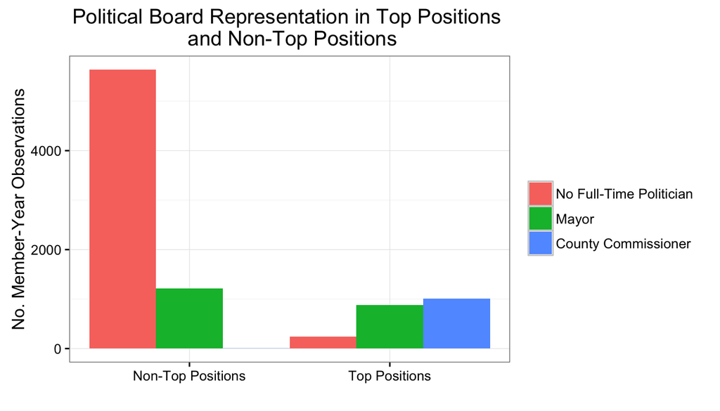

Overall, this shows that a considerable share of bank boards is hold by full-time politicians (34%). Moreover, political representation is pronounced in top positions of banks’ boards (county commissioners are only in top positions); as board seat holders of top positions have much higher influence on banks’ strategic decisions (e.g. as the chairman is always member of the credit committee), this finding confirms our suspicion that German *Sparkassen* are subject to potentially high political control and shows that politicization of public savings banks mainly works through top positions.

## 4.2. Election Data Set

Out of all the mayors elected the time period under study, 8.871% of the mayors who were elected were female.

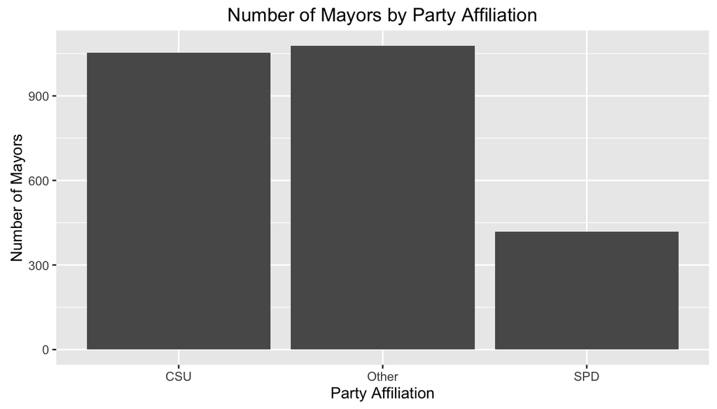

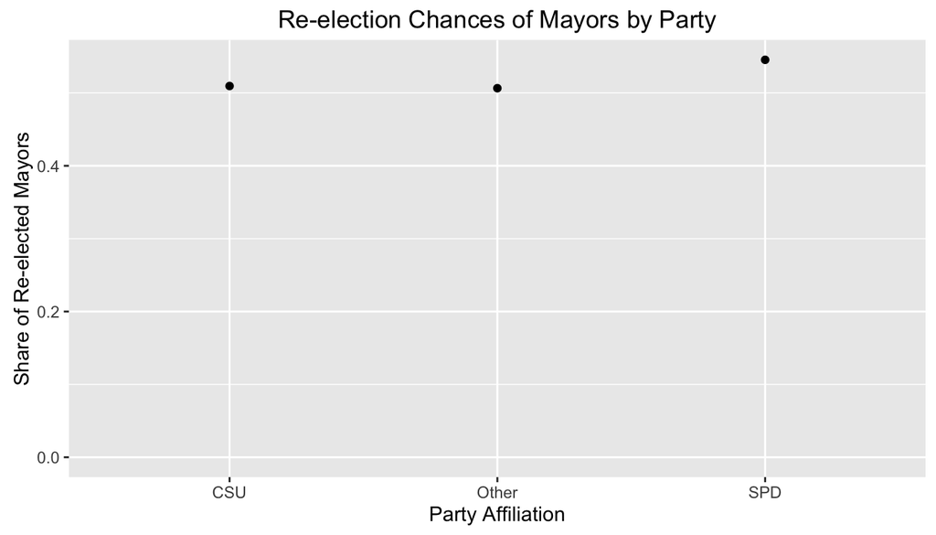

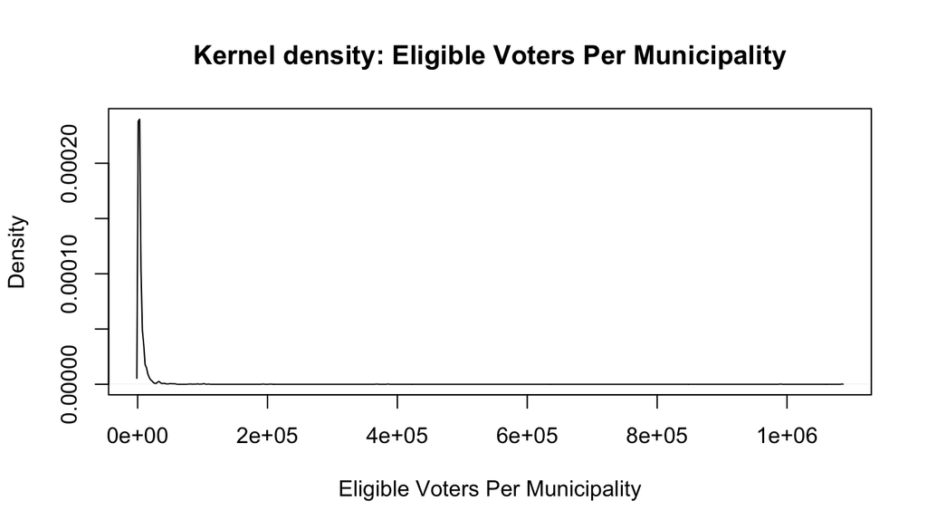

The number of eligible voters per municipality, which we intend to use to control for municipality size is severly right-skewed, as expected, so we will log it in our analysis.

# 5. First Inferences

Statistical models

|  | **Model 1** | **Model 2** | **Model 3** | **Model 4** |  |
| --- | --- | --- | --- | --- | --- |
| (Intercept) | 0.02 | 1.49*** | 0.82* | 0.72 |  |
|  | (0.04) | (0.15) | (0.41) | (0.41) |  |
| IncumbentSparkassenMemberTRUE | 0.25* | 0.25* | 0.24* | 0.24* |  |
|  | (0.11) | (0.11) | (0.11) | (0.11) |  |
| L.VoteShareWinner |  | -0.02*** | -0.02*** | -0.02*** |  |
|  |  | (0.00) | (0.00) | (0.00) |  |
| log(NumberEligVoter) |  |  | 0.08 | 0.08 |  |
|  |  |  | (0.04) | (0.04) |  |
| L.Geschlecht1w |  |  |  | 0.47* |  |
|  |  |  |  | (0.18) |  |
| AIC | 3530.27 | 3372.54 | 3371.39 | 3366.55 |  |
| BIC | 3541.96 | 3390.02 | 3394.70 | 3395.68 |  |
| Log Likelihood | -1763.14 | -1683.27 | -1681.70 | -1678.27 |  |
| Deviance | 3526.27 | 3366.54 | 3363.39 | 3356.55 |  |
| Num. obs. | 2549 | 2506 | 2506 | 2506 |  |
| p < 0.001, p < 0.01, p < 0.05 |  |  |  |  |  |

The regression tables for the different specifications show a stable, statistically slightly significant effect for board membership of the incumbent; the direction of the effect is as expected, i.e. incumbents with a board seat seem to be more likely to be re-elected than their counterparts without a seat in a *Sparkasse*. Surprisingly, the previous vote share of the incumbent is negatively correlated with incumbent’s re-election chances; the effect is statistically strongly significant[^3]. Furthermore, municipality size appears to have no statistically significant effect for the re-election chance of the mayor. Finally, female incumbents seem to be more likely be re-elected than male incumbents; the coefficient is however also only weakly statistically significant[^4].

[^1]: This dataset was collected as part of a research project by Guillermo Rosas (Washington University in St. Louis; grosas@wustl.edu) and Jonas Markgraf (Hertie School of Governance; markgraf@hertie-school.org).
[^2]: As the focus of this paper is the analysis of the electoral effect of board membership, we focus on the re-election chances of mayors with board membership in a *Sparkasse* compared to those without a board seat. A closer examination of the patterns of politicization of banks’ boards, such as partisanship within boards, is therefore not conducted and goes beyond the scope of this paper. Future steps of the PhD research project will, however, analyze those patterns.
[^3]: This result is alarming and indicates that our transformations are partly erroneous. This needs to be further investigated for the final paper.
[^4]: The direction of this coefficient is also surprising and requires further investigation, in particular of our specifications and transformations.